# Customization and Themes in ggplot2

2024

## Import `ggplot2` Library

```r
# Don't forget to load the ggplot2 library
library(ggplot2)
```

## Adjusting Text and Labels

```r
ggplot(data = mpg, aes(x = displ, y = hwy)) +
  geom_point(aes(color = class)) +
  labs(title = "Engine Displacement vs. Highway MPG",
       x = "Displacement (L)",
       y = "Highway MPG",
       color = "Vehicle Class")
```

## Adjusting Text and Labels

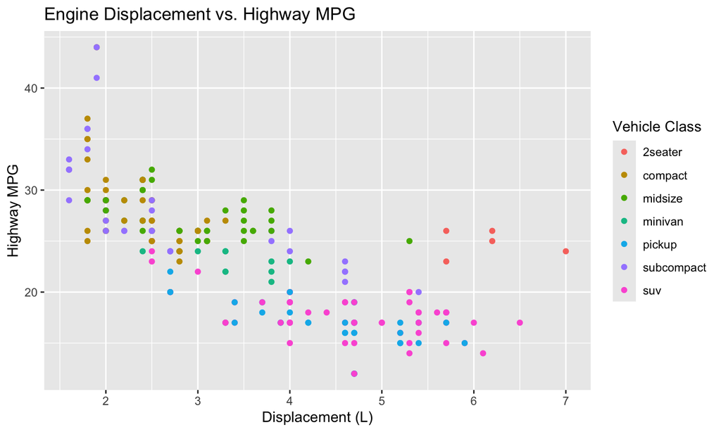

## Using Colors Effectively

```r
ggplot(data = mpg, aes(x = displ, y = hwy, color = class)) +
  geom_point() +
  scale_color_brewer(palette = "Set1")
```

## Using Colors Effectively

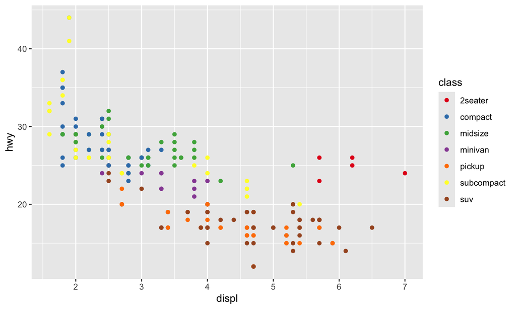

## Modifying Legend and Axis Properties

```r
ggplot(data = mpg, aes(x = displ, y = hwy)) +
  geom_point(aes(color = class)) +
  theme(legend.position = "top",
        axis.text.x = element_text(angle = 45, hjust = 1))
```

## Modifying Legend and Axis Properties

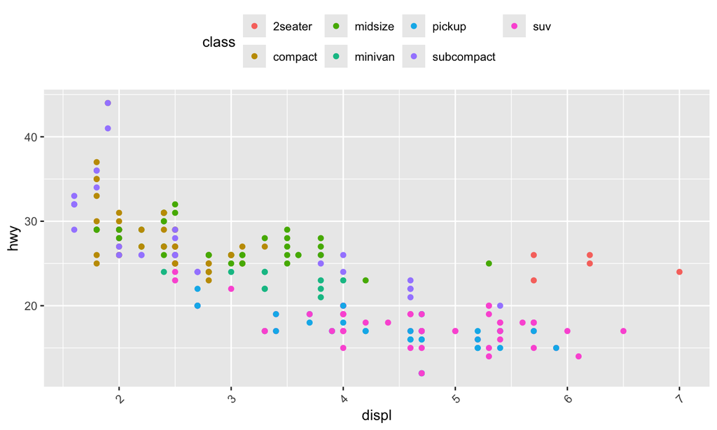

## Introduction to the theme() Function

```r
ggplot(data = mpg, aes(x = displ, y = hwy)) +
  geom_point() +
  labs(title = "Engine Displacement vs. Highway MPG",
       x = "Displacement (L)",
       y = "Highway MPG",
       color = "Vehicle Class") +
  theme(axis.title.x = element_text(face = "bold"),
        plot.title = element_text(hjust = 0.5))
```

## Introduction to the theme() Function

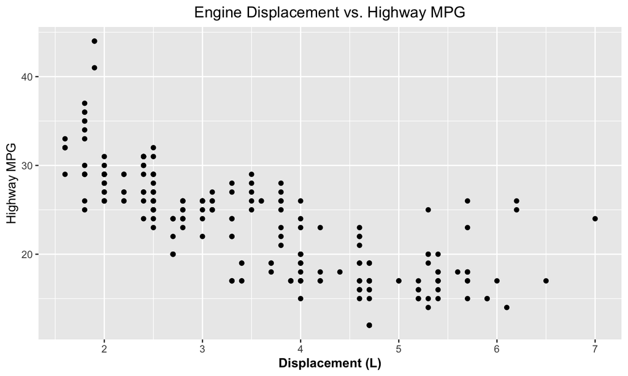

## Common argument to `theme`

- **text elements**:
  - `text`: General text appearance (applies to all text unless overridden).
  - `plot.title`: The plot title text.
  - `plot.subtitle`: The plot subtitle text.
  - `plot.caption`: The caption text.
  - `axis.title.x`, `axis.title.y`: X and Y axis titles.
  - `axis.text.x`, `axis.text.y`: X and Y axis text.
  - `legend.title`: The legend title text.
  - `legend.text`: The legend item texts.
- **legend**:
  - `legend.position`: Position of the legend (“none”, “left”, “right”, “bottom”, “top”, or two-element numeric vector).
  - `legend.background`: Background of the legend.
  - `legend.key`: Background of the legend keys.
  - `legend.box`: Arrangement of multiple legends (“horizontal” or “vertical”).
- **panel**:
  - `panel.background`: Background of the plotting area.
  - `panel.grid.major`, `panel.grid.minor`: Major and minor grid lines of the panel.
  - `panel.border`: Border around the plotting area.
- **axis lines**:
  - `axis.line.x`, `axis.line.y`: Lines along the X and Y axes.
- **strip** (for facets):
  - `strip.background`: Background of the facet labels.
  - `strip.text.x`, `strip.text.y`: Text of the facet labels along the X and Y direction.
- **plot margins**:
  - `plot.margin`: Margins around the entire plot.

## Fancy theme example

```
# Basic scatter plot
p <- ggplot(mpg, aes(x = displ, y = hwy)) +
  geom_point(aes(color = class)) +
  labs(title = "Engine Displacement vs. Highway MPG",
       x = "Displacement (liters)",
       y = "Highway MPG")

# Customize the plot
p + theme(
  # Customize plot title
  plot.title = element_text(face = "bold", size = 14, color = "blue"),

  # Customize panel background
  panel.background = element_rect(fill = "lightblue", colour = "black", linewidth = 1),

  # Customize axis lines
  axis.line = element_line(color = "darkblue", linewidth = 1),

  # Customize axis text
  axis.text.x = element_text(angle = 45, vjust = 1, hjust = 1),

  # Customize legend background
  legend.background = element_rect(fill = "lightgray", linewidth= 0.5, linetype = "solid"),

  # Customize legend title and text
  legend.title = element_text(face = "bold", size = 10, color = "darkred"),
  legend.text = element_text(size = 8)
)
```

## Fancy theme example

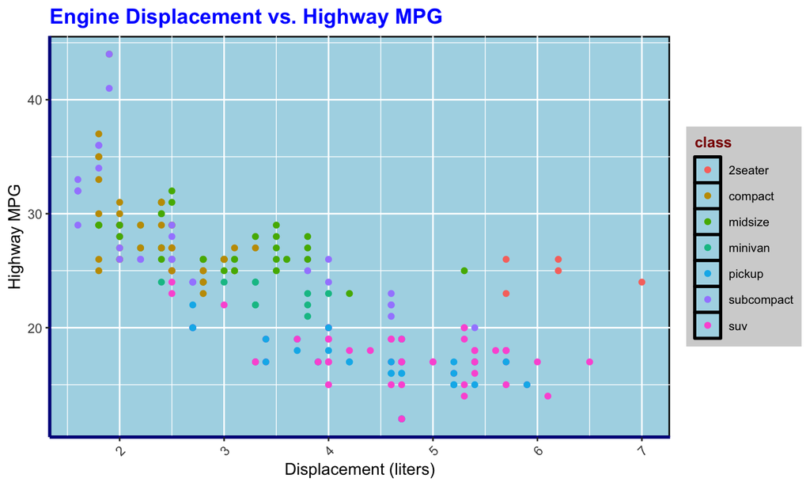

## Applying Pre-made Themes: Minimal

```r
# Minimal theme
ggplot(data = mpg, aes(x = displ, y = hwy)) +
  geom_point() +
  theme_minimal()
```

## Applying Pre-made Themes: Minimal

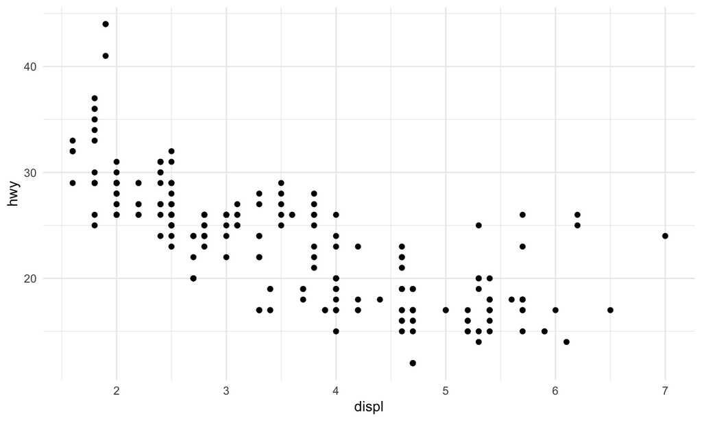

## Applying Pre-made Themes: Light

```r
# Light theme
ggplot(data = mpg, aes(x = displ, y = hwy)) +
  geom_point() +
  theme_light()
```

## Applying Pre-made Themes: Light

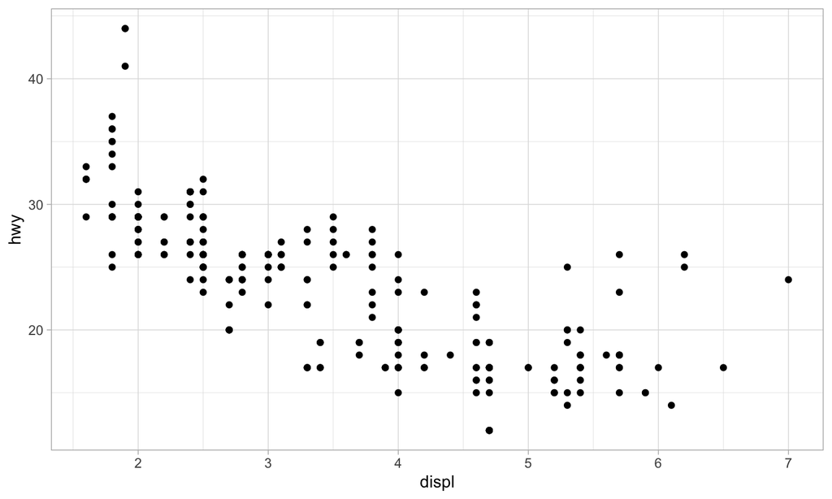

## Applying Pre-made Themes: Dark

```r
# Dark theme
ggplot(data = mpg, aes(x = displ, y = hwy)) +
  geom_point() +
  theme_dark()
```

## Applying Pre-made Themes: Dark

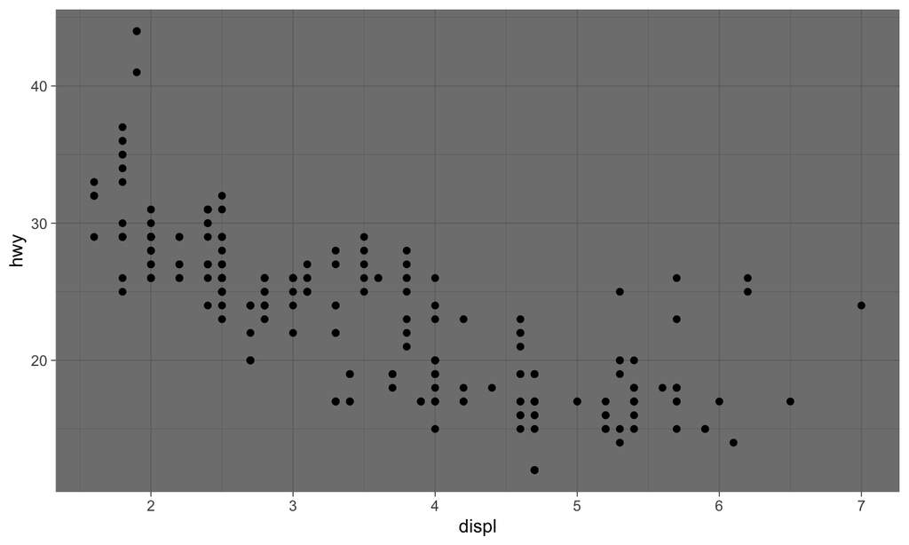

## Applying Pre-made Themes: Classic

```r
# Classic theme
ggplot(data = mpg, aes(x = displ, y = hwy)) +
  geom_point() +
  theme_classic()
```

## Applying Pre-made Themes: Classic

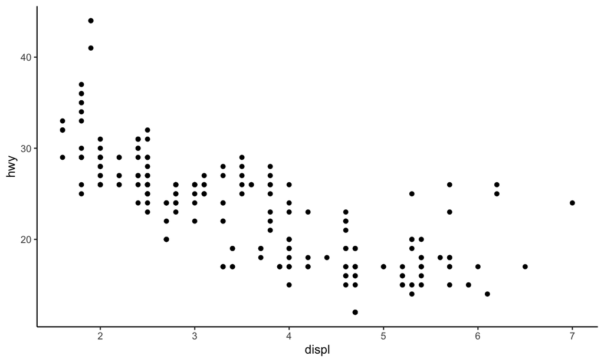

## Question

Change the title of the following to “Impact of Engine Displacement on Highway MPG”, make the x-axis title bold, and set the legend position to the bottom of the plot.

```r
ggplot(data = mpg, aes(x = displ, y = hwy, color = class)) +
  geom_point() +
  labs(x = "Displacement (L)",
       y = "Highway MPG",
       color = "Vehicle Class")
```

## Answer

**Click here for the answer**

```r
ggplot(data = mpg, aes(x = displ, y = hwy, color = class)) +
  geom_point() +
  labs(title = "Impact of Engine Displacement on Highway MPG",
       x = "Displacement (L)",
       y = "Highway MPG",
       color = "Vehicle Class") +
  theme(legend.position = "bottom",
        axis.title.x = element_text(face = "bold"))
```

## Question

Create a scatter plot using the `theme_dark()` with customized color for the plot background to a slightly lighter shade of grey given by ““#3E3E3E”.

```r
ggplot(data = mpg, aes(x = displ, y = hwy)) +
  geom_point() +
  theme_dark()
```

## Answer

**Click here for the answer**

```r
ggplot(data = mpg, aes(x = displ, y = hwy)) +
  geom_point() +
  theme_dark(base_size = 14) +
  theme(plot.background = element_rect(fill = "#3E3E3E"))
```

## Question

Apply the `theme_minimal()` to the following plot and adjust the axis text to be italic.

```r
ggplot(data = mpg, aes(x = class)) +
  geom_bar() +
  theme_minimal()
```

## Answer

**Click here for the answer**

```r
ggplot(data = mpg, aes(x = class)) +
  geom_bar(fill = "steelblue") +
  theme_minimal() +
  theme(axis.text.x = element_text(angle = 45, hjust = 1, face = "italic"),
        axis.text.y = element_text(face = "italic"))
```